# R Notebook

# “The teams that kick the most win games”

## Introduction

Following Englands victory against Ireland in November 2020, Eddie Jones was quoted “The teams that kick the most win games”.[^1] Even as early as 2010, the then Wales kicking coach can be quoted saying the same thing.[^2]. This analysis will examine those claims and see if there is any truth that teams that kick the most win the most.

### Packages

```r
library(corrr)
library(janitor)
library(tidyverse)
library(infer)
library(janitor)
library(lubridate)
library(tsibble)
library(rvest)
library(ggfortify)
library(GGally)
```

### Data

```r
# source("1_get_data/")

length(list.files("3_raw_data/team_data/"))
```

```
[1] 425
```

```r
international <- c(
  "australia", "new_zealand", "england", "south_africa", "ireland", "italy",
  "japan", "scotland", "wales", "france", "argentina", "georgia",
  "fiji", "romania", "usa", "tonga", "russia", "namibia",
  "samoa", "uruguay", "canada"
)
```

| Compitition | Type | Hemishpere |
| --- | --- | --- |
| Autumn Nations Cup | International | Northern |
| Currie Cup | Club | Southern |
| European Champions Cup | Club | Northern |
| Internationals | International | Mixed |
| Mitre 10 Cup | Club | Southern |
| Premiership | Club | Northern |
| Premiership Cup | Club | Northern |
| Pro 14 | Club | Northern |
| Rugby World Cup | International | Mixed |
| Six Nations | International | Northern |
| Super Rugby | Club | Southern |
| Super Rugby Aotearoa | Club | Southern |
| Super Rugby Australia | Club | Southern |
| Super Rugby Unlocked | Club | Southern |
| The Rugby Championship | International | Southern |

```r
team_data <- read_csv("5_clean_data/team_data.csv",
  col_types =
    cols(
      season = "c"
    )
)
```

Since we are focusing in kicking we need to select the points scored and number of kicks from hand. I have created columns and flagged each column to show the result of the match and flag which team had kicked the most. I have also created a column with the difference in the number of kicks .

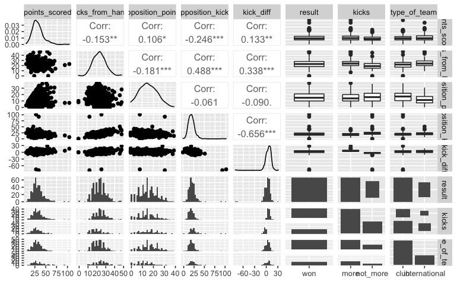

```r
matches <- team_data %>%
  filter(stat == "points_scored" | stat == "kicks_from_hand") %>%
  pivot_wider(names_from = stat, values_from = values) %>%
  group_by(date, match) %>%
  mutate(
    total_scored = sum(points_scored),
    total_kick = sum(kicks_from_hand)
  ) %>%
  ungroup() %>%
  mutate(
    opposition_points = total_scored - points_scored,
    opposition_kicks = total_kick - kicks_from_hand
  ) %>%
  select(-total_scored, -total_kick) %>%
  mutate(kick_diff = kicks_from_hand - opposition_kicks) %>%
  mutate(
    result = case_when(
      points_scored > opposition_points ~ "won",
      points_scored < opposition_points ~ "lost",
      points_scored == opposition_points ~ "draw"
    ),
    kicks =ifelse(kicks_from_hand > opposition_kicks, "more", "not_more")


  ) %>%
  mutate(type_of_team = if_else(team %in% international, "international", "club"))

type_of_team <- matches %>%
  select(team, type_of_team) %>%
  distinct(team, .keep_all = TRUE)

match_winners <- matches %>%
  filter(result == "won")

match_losers <- matches %>%
  filter(result == "lost")

match_winners %>%
  select(-competition:-team) %>%
  ggpairs(

  )
```

```r
match_winners
```

| competition | season | date | match | team | points_scored | kicks_from_hand | opposition_points | opposition_kicks | kick_diff | result | kicks | type_of_team |
| --- | --- | --- | --- | --- | --- | --- | --- | --- | --- | --- | --- | --- |
| internationals | 2019 | 2018-10-27 | new_zealand_vs_australia | new_zealand | 37 | 16 | 20 | 8 | 8 | won | more | international |
| internationals | 2019 | 2018-11-03 | england_vs_south_africa | england | 12 | 35 | 11 | 27 | 8 | won | more | international |
| internationals | 2019 | 2018-11-03 | ireland_vs_italy | ireland | 54 | 22 | 7 | 11 | 11 | won | more | international |
| internationals | 2019 | 2018-11-03 | japan_vs_new_zealand | new_zealand | 69 | 29 | 31 | 21 | 8 | won | more | international |
| internationals | 2019 | 2018-11-03 | wales_vs_scotland | wales | 21 | 32 | 10 | 25 | 7 | won | more | international |
| internationals | 2019 | 2018-11-10 | england_vs_new_zealand | new_zealand | 16 | 38 | 15 | 37 | 1 | won | more | international |
| internationals | 2019 | 2018-11-10 | france_vs_south_africa | south_africa | 29 | 37 | 26 | 36 | 1 | won | more | international |
| internationals | 2019 | 2018-11-10 | ireland_vs_argentina | ireland | 28 | 19 | 17 | 20 | -1 | won | not_more | international |
| internationals | 2019 | 2018-11-10 | italy_vs_georgia | italy | 28 | 16 | 10 | 13 | 3 | won | more | international |
| internationals | 2019 | 2018-11-10 | scotland_vs_fiji | scotland | 54 | 16 | 17 | 7 | 9 | won | more | international |

[output cut: 407 more lines]

# Analysis

## Team that kicks more than the opposition

Since the teams that kick the most is an ambiguous term I am to first focus on seeing if it is the case that the team that kicks more than their opposition wins the match

### Match Winners

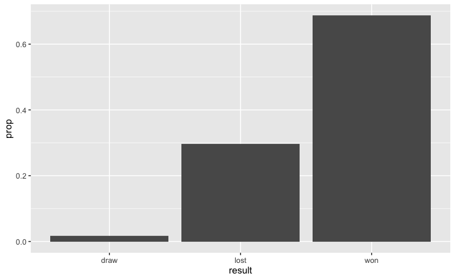

```r
matches %>%
  filter(kicks == "more") %>%
  mutate(kicks = str_to_title(kicks)) %>%
  ggplot() +
  aes(x = result, y = ..prop.., group = kicks, fill = type_of_team) +
  geom_bar(stat = "count")
```

## Hypothesis test

Using this data lets put that to the test if the claim is statistically significant. If kicking did not have an impact on matches you would expect the proportion of match wins to be around 50%

H0 = πmatches_won = 0.5 Ha - πmatches_won > 0.5

æ = 0.05

```r
test_matches <- matches %>%
  mutate(won = result == "won") %>%
  filter(kicks == "more")
```

```r
tset_matches_sample <- test_matches

null_distribution <- tset_matches_sample %>%
  specify(response = won, success = "TRUE") %>%
  hypothesize(null = "point", p = 0.5) %>%
  generate(reps = 10000, type = "simulate") %>%
  calculate(stat = "prop")

observed_stat <- tset_matches_sample %>%
  specify(response = won, success = "TRUE") %>%
  calculate(stat = "prop")
```

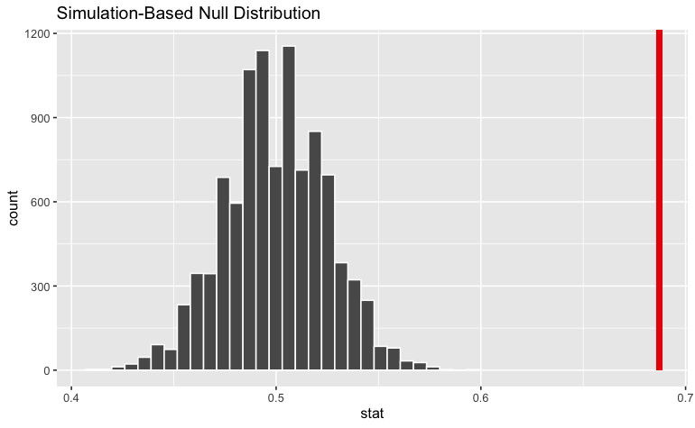

```r
null_distribution %>%
  visualise(bins = 30) + #remembering that it is a '+' here not '%>%' because using ggplot functionality to visualise
  shade_p_value(obs_stat = observed_stat, direction = "right")
```

```r
p_value <- null_distribution %>%
  get_p_value(obs_stat = observed_stat, direction = "both")
```

```
Please be cautious in reporting a p-value of 0. This result is an approximation based on the number of `reps` chosen in the `generate()` step. See `?get_p_value()` for more information.
```

```r
p_value
```

| p_value |
| --- |
| 0 |

The p-value is less than α we reject H0 in favour of Ha. We found enough evidence from our matches to suggest that the proportion of wins is statistically significantly greater than the null value. This means that statistically teams that kick more than their opposition win more games.

To do this I calculated the win percentage of the games played and the percentage of times they kicked more than their opposition.

```r
bootstrap_resample <- test_matches %>%
  specify(response = won, success = "TRUE") %>%
  generate(reps = 10000, type = "bootstrap") %>%
  calculate(stat = "prop")

churn_ci_95 <- bootstrap_resample %>%
  get_confidence_interval(level = 0.95, type = "percentile")

churn_ci_95
```

| lower_ci | upper_ci |
| --- | --- |
| 0.6430318 | 0.7334963 |

### Win Rate vs. Kick Rate

The win rate in this case is the percentage number of wins out their total number of matches. Kick rate is the percentage number of times a team kicked more than their opposition over their total number of matches.

```r
team_results <- matches %>%
  group_by(team, result) %>%
  summarise(count = n()) %>%
  ungroup() %>%
  pivot_wider(names_from = result, values_from = count) %>%
  mutate_if(is.numeric, ~ coalesce(.x, 0)) %>%
  rowwise() %>%
  mutate(
    no_matches = sum(draw, lost, won),
    win_rate = won / no_matches
  )
team_kicks <- matches %>%
  group_by(team, kicks) %>%
  summarise(count = n()) %>%
  ungroup() %>%
  pivot_wider(names_from = kicks, values_from = count) %>%
  mutate_if(is.numeric, ~ coalesce(.x, 0)) %>%
  rowwise() %>%
  mutate(
    no_matches = sum(more, not_more),
    kick_rate = more / no_matches
  ) %>%
  arrange(desc(kick_rate))
```

```r
team_rates <- team_results %>%
  left_join(team_kicks) %>%
  arrange(desc(kick_rate, win_rate))
```

### Top Ten teams with highest kick rate

```r
team_rates %>%
  filter(no_matches > 5) %>%
  ungroup() %>%
  mutate(rank = rank(-kick_rate, ties.method = "first"), .before = team) %>%
  slice_max(kick_rate, n = 10, with_ties = F) %>%
  select(-no_matches)
```

| rank | team | draw | lost | won | win_rate | more | not_more | kick_rate |
| --- | --- | --- | --- | --- | --- | --- | --- | --- |
| 1 | gwent_dragons | 0 | 7 | 3 | 0.3000000 | 8 | 2 | 0.8000000 |
| 2 | pumas | 0 | 9 | 1 | 0.1000000 | 8 | 2 | 0.8000000 |
| 3 | wasps | 0 | 3 | 6 | 0.6666667 | 7 | 2 | 0.7777778 |
| 4 | harlequins | 0 | 4 | 4 | 0.5000000 | 6 | 2 | 0.7500000 |
| 5 | new_zealand | 2 | 4 | 14 | 0.7000000 | 15 | 5 | 0.7500000 |
| 6 | blues | 0 | 4 | 10 | 0.7142857 | 10 | 4 | 0.7142857 |
| 7 | canterbury | 0 | 5 | 5 | 0.5000000 | 7 | 3 | 0.7000000 |
| 8 | south_africa | 1 | 3 | 9 | 0.6923077 | 9 | 4 | 0.6923077 |
| 9 | jaguares | 0 | 3 | 3 | 0.5000000 | 4 | 2 | 0.6666667 |
| 10 | ulster | 0 | 1 | 11 | 0.9166667 | 8 | 4 | 0.6666667 |

From this table we can see that these teams kick over 65% more times than their opposition, yet these teams also have mixed win rates

```r
team_rates %>%
  left_join(type_of_team) %>%
  filter(no_matches > 5) %>%
  ungroup() %>%
  mutate(rank = rank(-win_rate, ties.method = "first"), .before = team) %>%
  slice_max(win_rate, n = 10, with_ties = F) %>%
  select(-no_matches)
```

| rank | team | draw | lost | won | win_rate | more | not_more | kick_rate | type_of_team |
| --- | --- | --- | --- | --- | --- | --- | --- | --- | --- |
| 1 | ulster | 0 | 1 | 11 | 0.9166667 | 8 | 4 | 0.6666667 | club |
| 2 | munster | 0 | 1 | 9 | 0.9000000 | 6 | 4 | 0.6000000 | club |
| 3 | leinster | 0 | 1 | 9 | 0.9000000 | 5 | 5 | 0.5000000 | club |
| 4 | crusaders | 0 | 2 | 11 | 0.8461538 | 6 | 7 | 0.4615385 | club |
| 5 | sharks | 0 | 2 | 10 | 0.8333333 | 7 | 5 | 0.5833333 | club |
| 6 | wales | 0 | 4 | 18 | 0.8181818 | 13 | 9 | 0.5909091 | international |
| 7 | england | 1 | 3 | 17 | 0.8095238 | 12 | 9 | 0.5714286 | international |
| 8 | brumbies | 0 | 3 | 12 | 0.8000000 | 9 | 6 | 0.6000000 | club |
| 9 | hawkes_bay | 0 | 3 | 9 | 0.7500000 | 7 | 5 | 0.5833333 | club |
| 10 | tasman | 0 | 3 | 9 | 0.7500000 | 4 | 8 | 0.3333333 | club |

On the flip side the teams that have the higher win rates have mixed kick rates. Only Ulster appear in the top 10 both times. This also suggest that kicking more than the opposition does not mean that teams that kick more win games

### Correlation

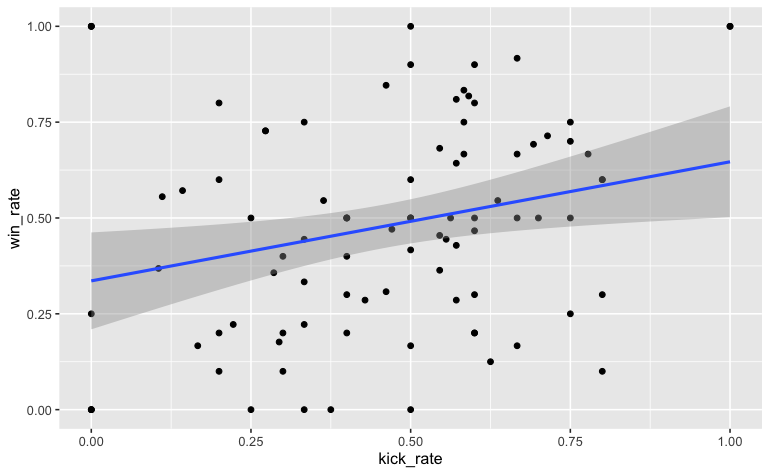

```r
team_rates %>%
  ggplot() +
  aes(x = kick_rate, y = win_rate) +
  geom_point() +
  geom_smooth(method = "lm")
```

```r
cor(team_rates$kick_rate, team_rates$win_rate)
```

```
[1] 0.2571644
```

If we plot the two variables together there a weak correlation of 0.257

## Top 10 teams by win rate

```r
avg_kicks <- matches %>%
  group_by(team) %>%
  summarise(avg_no_kicks_per_game = mean(kicks_from_hand))
team_kicks <- team_results %>%
  left_join(avg_kicks)
team_kicks %>%
  filter(no_matches > 5) %>%
  ungroup() %>%
  mutate(rank = rank(-win_rate, ties.method = "first"), .before = team) %>%
  slice_max(win_rate, n = 10, with_ties = F) %>%
  select(-no_matches)
```

| rank | team | draw | lost | won | win_rate | avg_no_kicks_per_game |
| --- | --- | --- | --- | --- | --- | --- |
| 1 | ulster | 0 | 1 | 11 | 0.9166667 | 24.16667 |
| 2 | leinster | 0 | 1 | 9 | 0.9000000 | 21.30000 |
| 3 | munster | 0 | 1 | 9 | 0.9000000 | 22.60000 |
| 4 | crusaders | 0 | 2 | 11 | 0.8461538 | 19.07692 |
| 5 | sharks | 0 | 2 | 10 | 0.8333333 | 21.00000 |
| 6 | wales | 0 | 4 | 18 | 0.8181818 | 26.18182 |
| 7 | england | 1 | 3 | 17 | 0.8095238 | 30.61905 |
| 8 | brumbies | 0 | 3 | 12 | 0.8000000 | 18.40000 |
| 9 | hawkes_bay | 0 | 3 | 9 | 0.7500000 | 19.33333 |
| 10 | tasman | 0 | 3 | 9 | 0.7500000 | 19.08333 |

Comparing the top 10 teams with their average number of kicks per game, there is a range between 18- 30. Again there is no clear order.

```r
team_kicks %>%
  filter(no_matches > 5) %>%
  ungroup() %>%
  mutate(rank = rank(-avg_no_kicks_per_game, ties.method = "first"), .before = team) %>%
  slice_max(avg_no_kicks_per_game, n = 10, with_ties = F) %>%
  select(-no_matches)
```

| rank | team | draw | lost | won | win_rate | avg_no_kicks_per_game |
| --- | --- | --- | --- | --- | --- | --- |
| 1 | western_force | 0 | 8 | 0 | 0.0000000 | 37.12500 |
| 2 | england | 1 | 3 | 17 | 0.8095238 | 30.61905 |
| 3 | france | 0 | 8 | 8 | 0.5000000 | 28.62500 |
| 4 | harlequins | 0 | 4 | 4 | 0.5000000 | 28.37500 |
| 5 | scarlets | 0 | 4 | 6 | 0.6000000 | 26.90000 |
| 6 | south_africa | 1 | 3 | 9 | 0.6923077 | 26.30769 |
| 7 | wales | 0 | 4 | 18 | 0.8181818 | 26.18182 |
| 8 | ospreys | 0 | 5 | 4 | 0.4444444 | 25.88889 |
| 9 | cardiff_blues | 0 | 6 | 4 | 0.4000000 | 24.90000 |
| 10 | gwent_dragons | 0 | 7 | 3 | 0.3000000 | 24.90000 |

```r
matches %>%
  group_by(type_of_team) %>%
  summarise(avg_no_kicks_per_games = mean(kicks_from_hand))
```

| type_of_team | avg_no_kicks_per_games |
| --- | --- |
| club | 20.85294 |
| international | 23.36134 |

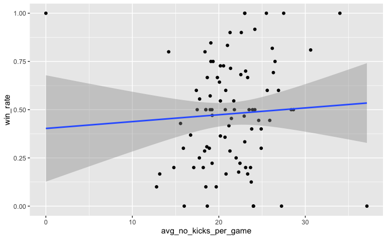

```r
team_kicks %>%
  ggplot() +
  aes(x = avg_no_kicks_per_game, y = win_rate) +
  geom_point() +
  geom_smooth(method = lm)
```

```r
correlate(team_kicks$avg_no_kicks_per_game, team_kicks$win_rate)
```

```
Correlation method: 'pearson'
Missing treated using: 'pairwise.complete.obs'
```

| term | x |
| --- | --- |
| x | 0.05926988 |

If we the look at the correlation we can see that there is even less of a correlation between the average number of kicks and win rate.

```
the standard deviation is zero
Correlation method: 'pearson'
Missing treated using: 'pairwise.complete.obs'
```

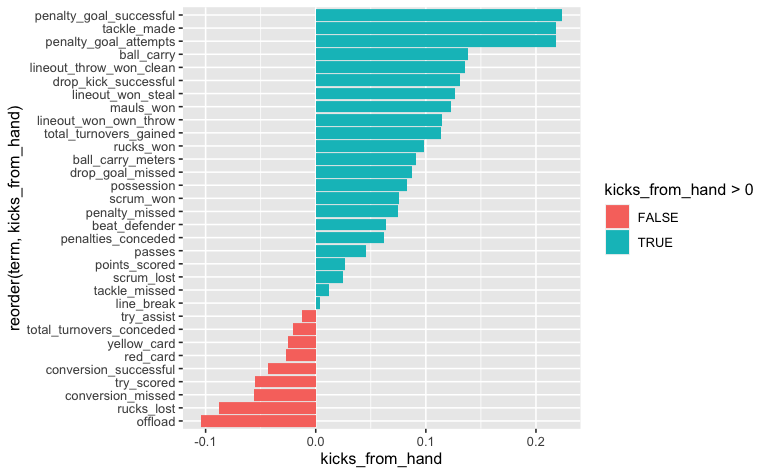

```r
data <- team_data %>%
  pivot_wider(names_from = stat, values_from = values) %>%
  rowwise %>%
  mutate(penalty_goal_attempts = penalty_goal_successful + penalty_missed)

  data %>%
  select(-competition:-team) %>%
  correlate() %>%
  focus(kicks_from_hand) %>%
  ggplot()+
  aes(x = reorder(term, kicks_from_hand), y = kicks_from_hand, fill = kicks_from_hand > 0) +
  geom_col() +
  coord_flip()
```

```r
  data %>%
  select(-competition:-team) %>%
  correlate() %>%
  focus(points_scored)
```

```
the standard deviation is zero
Correlation method: 'pearson'
Missing treated using: 'pairwise.complete.obs'
```

| term | points_scored |
| --- | --- |
| try_scored | 0.932387067 |
| ball_carry_meters | 0.383649378 |
| ball_carry | 0.170532913 |
| beat_defender | 0.288160147 |
| line_break | 0.455971867 |
| passes | 0.197658535 |
| offload | 0.241279101 |
| total_turnovers_conceded | -0.120297465 |
| try_assist | 0.704151610 |
| tackle_made | -0.067085130 |

[output cut: 22 more lines]

```r
data <- data %>%
  select(-competition:-team, - c(penalty_goal_successful, penalty_missed))
```

```r
data %>%
  correlate() %>%
  focus(penalty_goal_attempts) %>%
  arrange(desc(penalty_goal_attempts))
```

```
the standard deviation is zero
Correlation method: 'pearson'
Missing treated using: 'pairwise.complete.obs'
```

| term | penalty_goal_attempts |
| --- | --- |
| kicks_from_hand | 0.217952824 |
| drop_goal_missed | 0.169811360 |
| lineout_won_steal | 0.081933066 |
| drop_kick_successful | 0.058835915 |
| total_turnovers_gained | 0.056738377 |
| scrum_lost | 0.049212905 |
| penalties_conceded | 0.033764845 |
| possession | 0.010977117 |
| rucks_lost | 0.002454991 |
| points_scored | 0.001710959 |

[output cut: 20 more lines]

```r
model<-lm(penalty_goal_attempts~ kicks_from_hand, data = data)

summary(model)
```

```
Call:
lm(formula = penalty_goal_attempts ~ kicks_from_hand, data = data)

Residuals:
    Min      1Q  Median      3Q     Max
-4.9484 -1.3651 -0.3615  1.0869 14.9411

Coefficients:
                Estimate Std. Error t value Pr(>|t|)
(Intercept)     0.916726   0.176245   5.201 2.48e-07 ***
kicks_from_hand 0.049819   0.007661   6.503 1.34e-10 ***
---
Signif. codes:  0 ‘***’ 0.001 ‘**’ 0.01 ‘*’ 0.05 ‘.’ 0.1 ‘ ’ 1

Residual standard error: 1.796 on 848 degrees of freedom
Multiple R-squared:  0.0475,    Adjusted R-squared:  0.04638
F-statistic: 42.29 on 1 and 848 DF,  p-value: 1.342e-10
```

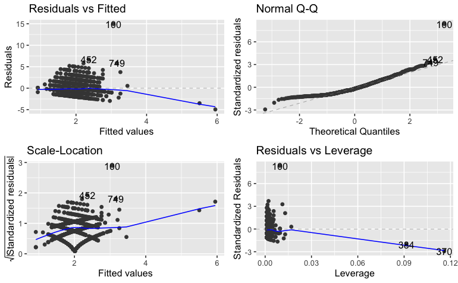

```r
library(modelr)
autoplot(model)
```

```r
residuals <- data %>%
  add_residuals(model) %>%
  select(-c(kicks_from_hand, penalty_goal_attempts))

residuals %>%
  correlate() %>%
  focus(resid)
```

```
the standard deviation is zero
Correlation method: 'pearson'
Missing treated using: 'pairwise.complete.obs'
```

| term | resid |
| --- | --- |
| try_scored | -0.287062419 |
| ball_carry_meters | -0.055420257 |
| ball_carry | -0.091098535 |
| beat_defender | -0.065971797 |
| line_break | -0.088022583 |
| passes | -0.091702327 |
| offload | -0.068974451 |
| total_turnovers_conceded | -0.118353075 |
| try_assist | -0.196579699 |
| points_scored | -0.004281438 |

[output cut: 19 more lines]

```r
model2 <- lm(penalty_goal_attempts~ kicks_from_hand + try_scored, data = data)

summary(model2)
```

```
Call:
lm(formula = penalty_goal_attempts ~ kicks_from_hand + try_scored,
    data = data)

Residuals:
   Min     1Q Median     3Q    Max
-5.143 -1.286 -0.286  1.042 14.540

Coefficients:
                 Estimate Std. Error t value Pr(>|t|)
(Intercept)      1.715022   0.192037   8.931  < 2e-16 ***
kicks_from_hand  0.046260   0.007353   6.291 5.04e-10 ***
try_scored      -0.244071   0.027938  -8.736  < 2e-16 ***
---
Signif. codes:  0 ‘***’ 0.001 ‘**’ 0.01 ‘*’ 0.05 ‘.’ 0.1 ‘ ’ 1

Residual standard error: 1.721 on 847 degrees of freedom
Multiple R-squared:  0.1262,    Adjusted R-squared:  0.1242
F-statistic: 61.18 on 2 and 847 DF,  p-value: < 2.2e-16
```

```r
residuals <-data %>%
  add_residuals(model2) %>%
  select(-c(kicks_from_hand, penalty_goal_attempts, try_scored))

residuals %>%
  correlate() %>%
  focus(resid)
```

```
the standard deviation is zero
Correlation method: 'pearson'
Missing treated using: 'pairwise.complete.obs'
```

| term | resid |
| --- | --- |
| ball_carry_meters | 0.054495888 |
| ball_carry | -0.038921975 |
| beat_defender | 0.013735087 |
| line_break | 0.048425569 |
| passes | -0.030164763 |
| offload | 0.006995609 |
| total_turnovers_conceded | -0.143995045 |
| try_assist | 0.016704113 |
| points_scored | 0.276292115 |
| tackle_made | -0.082864830 |

[output cut: 18 more lines]

[^1]: https://www.macclesfieldrufc.co.uk/2020/12/what-should-our-game-look-like-in-2021/
[^2]: https://www.theguardian.com/sport/2010/feb/01/wales-lee-byrne-six-nations-ban